# Google Location History

Emeline

October 21, 2016

## Background

I used to not leave the GPS tracking on my phone on because I thought it would conserve battery. However, I managed to lose a phone that I had just bought three weeks before, so now I leave location services on all the time… So I wanted to see if there was anything interesting in my data.

You can download all of the data that Google has collected on you [here](https://takeout.google.com/settings/takeout?utm_source=ob&utm_campaign=takeout&hl=en). I checked off only the Location History (JSON Format), which I downloaded as a .zip.

## Data Exploration

Following [an excellent post on StackExchange](http://stackoverflow.com/a/30854697), this is how I read in the location history datah:

```r
library(jsonlite)
system.time(x <- fromJSON("/home/emeline/Desktop/Takeout/Location History/LocationHistory.json"))
```

```
##    user  system elapsed
## 212.548   0.544 224.807
```

```r
loc = x$locations
loc$time = as.POSIXct(as.numeric(x$locations$timestampMs)/1000,
                      origin = "1970-01-01")

loc$lat = loc$latitudeE7 / 1e7
loc$lon = loc$longitudeE7 / 1e7
head(loc)
```

```
##     timestampMs latitudeE7 longitudeE7 accuracy velocity altitude
## 1 1476840301000  410179526  -740186461        6        0      -18
## 2 1476840294896  410177916  -740186968       24       NA       NA
## 3 1476840209817  410177916  -740186968       24       NA       NA
## 4 1476840176336  410177900  -740186967       26       NA       NA
## 5 1476840123926  410178318  -740186584       35       NA       NA
## 6 1476840105231  410178926  -740186741       50       NA       NA
##                                                                                   activitys
## 1                                                                                      NULL
## 2 1476840296939, still, inVehicle, unknown, onFoot, walking, onBicycle, 54, 23, 17, 4, 4, 2
## 3                                                                                      NULL
## 4                                                                                      NULL
## 5                                                                                      NULL
## 6                                                                 1476840084800, still, 100
##   heading                time      lat       lon
## 1      NA 2016-10-18 21:25:01 41.01795 -74.01865
## 2      NA 2016-10-18 21:24:54 41.01779 -74.01870
## 3      NA 2016-10-18 21:23:29 41.01779 -74.01870
## 4      NA 2016-10-18 21:22:56 41.01779 -74.01870
## 5      NA 2016-10-18 21:22:03 41.01783 -74.01866
## 6      NA 2016-10-18 21:21:45 41.01789 -74.01867
```

Also following the post, I plotted a trajectory graph:

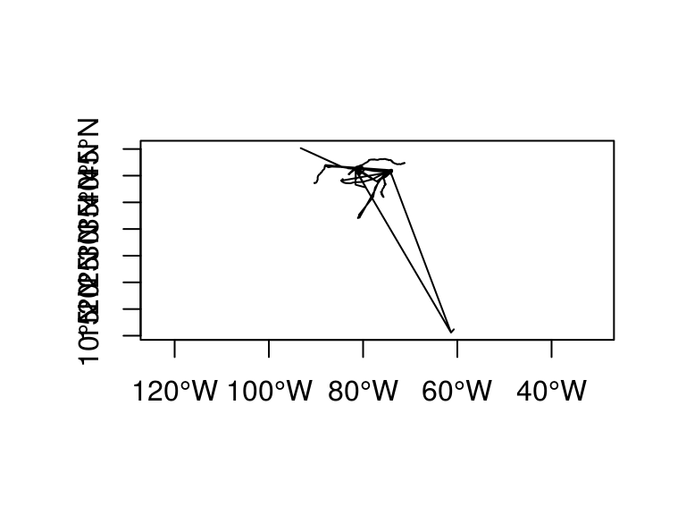

```r
library(sp)
loc.sp = loc
coordinates(loc.sp) = ~lon+lat
proj4string(loc.sp) = CRS("+proj=longlat +datum=WGS84")

library(spacetime)
library(trajectories)
tr = Track(STIDF(geometry(loc.sp), loc.sp$time, loc.sp@data))
plot(tr)
```

I was intrigued by the inclusion of altitude information, so I wanted to see what a 3d plot would look like:

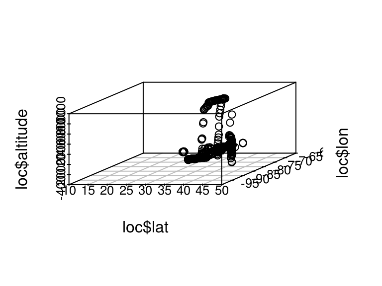

```r
library(scatterplot3d)
scatterplot3d(loc$lat, loc$lon, loc$altitude)
```

I didn’t think it was super helpful….

From here, I decided on the first things I wanted to look at: what was going on when I was higher in altitude, and where were my most commonly visited places.

### High Altitude

I decided I would filter the location dataframe by when my altitude was greater than 500 and then plot those points against a map.

```r
highalt<-loc[which(loc$altitude>500), ]

library(ggmap)
```

[figure not shown]

```r
map<-get_googlemap(center=c(lon=-80, lat=40), zoom=6, maptype="roadmap")
mapHighAlt<-ggmap(map)+geom_point(aes(x = lon, y = lat, colour="red"), data=highalt)
mapHighAlt
```

I know I’ve flown to Cleveland for school and then Cincinatti for work. It is interesting to see that I was high in altitude closer to home; I’m not sure what that exactly corresponds to. I’ve also flown to more places in recent memory, but probably left my phone off…

Weirdly, not sure what the random dot is above Virginia.

### Most Frequent Locations

Based on the command below, looks like info has been collected since the end of 2013. I decided to use a frequency of 300 as a cutoff.

```r
min(loc$time)
```

```
## [1] "2013-11-05 08:21:56 EST"
```

I used the count() function from plyr to check the frequency of coordinates being used:

[figure not shown]

```r
library(plyr)
freq = count(loc, c('lon', 'lat'))
#Setting 300 as the cutoff:
highfreq=freq[which(freq$freq>300), ]

library(ggmap)
mapfreq<-get_googlemap(center=c(lon=-76.5, lat=41), zoom=6, maptype="roadmap")
mapPoints <- ggmap(mapfreq)+geom_point(aes(x = lon, y = lat, size = sqrt(freq), colour = sqrt(freq)), data=highfreq, alpha = .8)
mapPoints
```

Further explorations to follow!